# Research: An Exploration of BMW 1er Used Cars on an online Marketplace

by Chung-Han Lee

1. Pre-words  
   1-1. Motivation  
   1-2. Data Source  
   1-3. Tools and skill
2. Prepare Data  
   2-1. Introduction of scraped data  
   2-2. Data wrangling
3. Price prediction  
   3-1. Exploration  
   3-2. Price model based on age  
   3-3. Price model modified with horsepower  
   3-4. Price predict - regression by machine learning with NLP  
   3-4-1. Feature Engineering  
   3-4-2. Train test set split  
   3-4-3. First try on linear regression  
   3-4-4. Pipeline and Gridsearch  
   3-4-5. Improvement by the exponential model  
   3-4-6. Quick question: how much more could an 1er M Coupé cost than M140?  
   3-4-7. Quick question: how much more could automatic cost than manual?  
   3-4-8. Quick question: do dealers always sell more expensive than private?  
   3-4-9. Significant features  
   3-5. Summary  
   3-6. Future work
4. Insight from age of the car  
   4-1. Relation between ages and models  
   4-2. New promotion ways hide behind - leasing  
   4-3. Summary  
   4-4. Future work
5. Data visualization on map  
   5-1. Preparation  
   5-2. Where are those cars sold?  
   5-3. Is there any significant age difference between areas?  
   5-4. Where are more dealers than private sellers? And the other way round?

# Pre-words

## Motivation

In the mid of 2020, I wanted to buy a new second hand car to replace my old one. And at that time, my ideal type was BMW. After I roughly surfed on several car dealer portals, more and more questions came to my mind, for example,

- what are the key points to a price, e.g. how long the car has been produced and used, or the horsepower?
- does auto-gear cost more than manual? if, yes, roughly how much. Is there still many manual car?
- do manufacturer-authorized dealer require higher prices?
- ...and much more

Since two years I began to leanr data science and am curious if what I have learned can give an overview to this puzzle.

## Data Source

The data used in this project were scraped in the last two weeks of July 2020, from a online protal based in Germany and provided EU-wide. These data are not used for business purposes, but only for my research.

The total amount of my data is ca. 55000. I will only used BMW 1er data (ca. 8500) for this project.  
Data only range those cars first-registered from Jan 2010.

## Tools and skill

In this project, I will demo how I handle data with

1. regular expression
2. data visualization skill
3. natual language process (NLP)
4. application of machine learning

# Prepare Data

## Introduction of scraped data

at first, I would like to show how the scraped data look like.

```
database contains 54660 data
```

|  | model | condition | gear_type | fuel_type | price | mileage | first_reg | power_ps | power_kw | conditions | drive | tags | characters | environment | equipment | vendor | description | link |
| --- | --- | --- | --- | --- | --- | --- | --- | --- | --- | --- | --- | --- | --- | --- | --- | --- | --- | --- |
| 0 | 230 | Gebraucht | Automatik | Benzin | 21890 | 56200.0 | 07/2017 | 252.0 | 185.0 | Zustand: Gebraucht, Fahrzeughalter: 1, HU Prüf... | Getriebeart: Automatik, Hubraum: 1.998 cm³ |  | Marke: BMW, Modell: 230, Erstzulassung: 2017, ... | Kraftstoff: Benzin, Schadstoffklasse: Euro 6, ... | Komfort: [Armlehne ,Einparkhilfe ,Einparkhilfe... | vendor: Auto - Galerie - 24 GmbH, reviews: 7, ... | S1CAA Selektion COP relevanter Fahrzeuge S2DTA... | https://www.autoscout24.de/angebote/bmw-230-i-... |
| 1 | 230 | Gebraucht | Automatik | Benzin | 26500 | 28500.0 | 07/2018 | 252.0 | 185.0 | Zustand: Gebraucht, Fahrzeughalter: 1, HU Prüf... | Getriebeart: Automatik, Hubraum: 1.998 cm³, An... |  | Marke: BMW, Modell: 230, Erstzulassung: 2018, ... | Kraftstoff: Benzin, Schadstoffklasse: Euro 6, ... | Komfort: [Armlehne ,Einparkhilfe ,Einparkhilfe... | vendor: Auto - Galerie - 24 GmbH, reviews: 7, ... | Irrtümer Schreibfehler oder zwischenzeitlichen... | https://www.autoscout24.de/angebote/bmw-230-x-... |
| 2 | 230 | Gebraucht | Automatik | Benzin | 26500 | 27350.0 | 02/2017 | 252.0 | 185.0 | Zustand: Gebraucht, Fahrzeughalter: 2, HU Prüf... | Getriebeart: Automatik, Hubraum: 1.998 cm³, An... | Sportsitze, Sitzheizung, Einparkhilfe, Navigat... | Marke: BMW, Modell: 230, Angebotsnummer: B0091... | Kraftstoff: Super 95 / Super Plus 98, Andere E... | Komfort: [Armlehne ,Einparkhilfe ,Einparkhilfe... | vendor: Klaus Scheller GmbH, reviews: 18, cont... | Sitzbezug:Stoff-/Lederkombination 'Breeze' Ant... | https://www.autoscout24.de/angebote/bmw-230-i-... |
| 3 | 230 | Gebraucht | Automatik | Benzin | 26900 | 17476.0 | 10/2016 | 252.0 | 185.0 | Zustand: Gebraucht, Fahrzeughalter: 1, HU Prüf... | Getriebeart: Automatik, Gänge: 8, Hubraum: 1.9... | Sportpaket, Sportfahrwerk, Einparkhilfe Kamera... | Marke: BMW, Modell: 230, Angebotsnummer: 32013... | Kraftstoff: Super 95, Kraftstoffverbrauch: 6,4... | Komfort: [Einparkhilfe ,Einparkhilfe Kamera ,E... | vendor: Procar Automobile GmbH, reviews: 19, c... | Sonderausstattung216 Servotronic2L9 18' Leicht... | https://www.autoscout24.de/angebote/bmw-230-i-... |
| 4 | 230 | Gebraucht | Automatik | Benzin | 26990 | 7990.0 | 12/2016 | 252.0 | 185.0 | Zustand: Gebraucht, Fahrzeughalter: 1, HU Prüf... | Getriebeart: Automatik, Gänge: 8, Hubraum: 1.9... | Sportpaket, Einparkhilfe selbstlenkendes Syste... | Marke: BMW, Modell: 230, Angebotsnummer: 63231... | Kraftstoff: Super 95, Kraftstoffverbrauch: 5,7... | Komfort: [Armlehne ,Berganfahrassistent ,Einpa... | vendor: Drexl + Ziegler GmbH & Co. KG, reviews... | Zum Fahrzeugkauf bieten wir Ihnen folgenden Se... | https://www.autoscout24.de/angebote/bmw-230-i-... |

The most features here are understandable, either numerical or have been categorized. Besides this website also let seller add tags and description. I will use them for NLP.

Here I am showing one of the data and its type.

```
model                                                        230
condition                                              Gebraucht
gear_type                                              Automatik
fuel_type                                                 Benzin
price                                                      26500
mileage                                                  27350.0
first_reg                                                02/2017
power_ps                                                   252.0
power_kw                                                   185.0
conditions     Zustand: Gebraucht, Fahrzeughalter: 2, HU Prüf...
drive          Getriebeart: Automatik, Hubraum: 1.998 cm³, An...
tags           Sportsitze, Sitzheizung, Einparkhilfe, Navigat...
characters     Marke: BMW, Modell: 230, Angebotsnummer: B0091...
environment    Kraftstoff: Super 95 / Super Plus 98, Andere E...
equipment      Komfort: [Armlehne ,Einparkhilfe ,Einparkhilfe...
vendor         vendor: Klaus Scheller GmbH, reviews: 18, cont...
description    Sitzbezug:Stoff-/Lederkombination 'Breeze' Ant...
link           https://www.autoscout24.de/angebote/bmw-230-i-...
Name: 2, dtype: object
```

```
model           object
condition       object
gear_type       object
fuel_type       object
price            int64
mileage        float64
first_reg       object
power_ps       float64
power_kw       float64
conditions      object
drive           object
tags            object
characters      object
environment     object
equipment       object
vendor          object
description     object
link            object
dtype: object
```

## Data wrangling

Data wrangling requires a big effort and a relatively complex process. Therefore I will not get into details here.  
The targets of my data wrangling here are:

1. fill missing data by probability (e.g. finding similar data and calculate which is most possible)
2. convert data type, for example, register date from string to time-stamp, which can be more widely used in visualization
3. convert tags/tokens into lists or dicts for NLP
4. remove data missing too much information

```
Hint for hidden cell: data wrangling definitions done
```

Here, as said, the 1er data are selected out.

```
1er has 8740 data
```

|  | series | model | price | condition | gear_type | fuel_type | mileage | first_reg | age_mon | power_ps | ... | seller | postcode | city | reviews | kw_comfort | kw_extras | kw_media | kw_safety | tags | description |
| --- | --- | --- | --- | --- | --- | --- | --- | --- | --- | --- | --- | --- | --- | --- | --- | --- | --- | --- | --- | --- | --- |
| 366 | 1 | 116 | 5000 | Gebraucht | manual | Diesel | 170000 | 2010-05-01 | 122 | 116 | ... | private | 22941 | Bargteheide | -1 | [Einparkhilfe Sensoren hinten, Elektr. Fenster... | [Alufelgen, Winterreifen] | [Bordcomputer, CD, MP3, Radio] | [ABS, Beifahrerairbag, ESP, Fahrerairbag, Isof... | [bordcomputer, fahrerairbag, zentralverriegelu... | Ich verkaufe mein gepflegten 116d, Er hat schö... |
| 3259 | 1 | 118 | 8900 | Gebraucht | manual | Benzin | 111500 | 2010-02-01 | 125 | 143 | ... | private | 87700 | Memmingen | -1 | [Armlehne, Einparkhilfe, Einparkhilfe Sensoren... | [Alufelgen, Sommerreifen, Sportfahrwerk, Sport... | [Bluetooth, Bordcomputer, Freisprecheinrichtun... | [ABS, Beifahrerairbag, ESP, Fahrerairbag, Kopf... | [sportfahrwerk, sportsitze, sportpaket, getönt... | M-Paket- Dachhimmel Anthrazit- M-Multifunktion... |
| 8406 | 1 | 135 | 20950 | Gebraucht | manual | Benzin | 82000 | 2014-01-01 | 78 | 320 | ... | private | 21217 | Seevetal | -1 | [Armlehne, Elektr. Fensterheber, Elektrische S... | [Scheinwerferreinigung, Sportfahrwerk] | [Bordcomputer, CD, Radio] | [ABS, Beifahrerairbag, ESP, Fahrerairbag, Isof... | [xenonscheinwerfer, wegfahrsperre, sportfahrwe... | Das Fahrzeug hatte mal ein Parkschaden Wo es d... |
| 3142 | 1 | 118 | 4890 | Gebraucht | manual | Benzin | 192958 | 2010-08-01 | 119 | 143 | ... | ES TRADING | 72474 | Winterlingen | 0 | [Armlehne, Einparkhilfe, Einparkhilfe Sensoren... | [Alufelgen, Raucherpaket, Sportfahrwerk, Sport... | [Bordcomputer, CD, Radio] | [ABS, Airbag hinten, Beifahrerairbag, ESP, Fah... | [] | BMW 118i Limousine mit M PAKET, Sonderausstatt... |
| 4066 | 1 | 118 | 12990 | Gebraucht | manual | Benzin | 71273 | 2015-03-01 | 64 | 170 | ... | A. M. Autocenter | 37081 | Göttingen | 45 | [Armlehne, Einparkhilfe, Einparkhilfe Sensoren... | [Alufelgen, Sportsitze] | [Bordcomputer, CD, Freisprecheinrichtung, Radio] | [ABS, Beifahrerairbag, ESP, Fahrerairbag, Isof... | [klimaanlage, sportsitze, einparkhilfe, freisp... | Innenausstattung, Stoff, Becherhalter, Mittela... |

5 rows × 39 columns

The columns and its type:

```
Index(['series', 'model', 'price', 'condition', 'gear_type', 'fuel_type',
       'mileage', 'first_reg', 'age_mon', 'power_ps', 'owner',
       'guarantee_months', 'smoke-free', 'next_HU', 'full_service_history',
       'drive_type', 'eng_disp', 'doors', 'ext_color', 'int_color', 'body',
       'country_ver', 'seats', 'emission', 'particulate_sticker',
       'consume_combine', 'consume_in_town', 'consume_out_of_town',
       'emission_class', 'seller', 'postcode', 'city', 'reviews', 'kw_comfort',
       'kw_extras', 'kw_media', 'kw_safety', 'tags', 'description'],
      dtype='object')
```

```
series                          object
model                           object
price                            int64
condition                       object
gear_type                       object
fuel_type                       object
mileage                          int64
first_reg               datetime64[ns]
age_mon                          int64
power_ps                         int64
owner                            int64
guarantee_months                object
smoke-free                       int64
next_HU                          int64
full_service_history             int64
drive_type                      object
eng_disp                         int64
doors                            int64
ext_color                       object
int_color                       object
body                            object
country_ver                     object
seats                            int64
emission                         int64
particulate_sticker              int64
consume_combine                float64
consume_in_town                float64
consume_out_of_town            float64
emission_class                  object
seller                          object
postcode                        object
city                            object
reviews                          int64
kw_comfort                      object
kw_extras                       object
kw_media                        object
kw_safety                       object
tags                            object
description                     object
dtype: object
```

Here are the explaination of each feature

1. series (str): 1er, 2er,... here only 1er is selected out, thus all are "1"
2. model (str): 114, 116, 118,...
3. price (int): price in EUR
4. condition (str): Neu (new), Jahreswagen (year car), Gebraucht (used),...
5. gear_type (str): manual or automatic
6. fuel_type (str): Benzin (petrol) or Diesel
7. mileage (int): mileage in km
8. first_reg (str): month/year of when the car firstly registered
9. age_mon (int): age in month derived from first_reg
10. power_ps (int): horsepower
11. owner (int): how many pre-owner (-1 means unknown)
12. guarantee_months (int/obj): either be int (how many months guarantee) or be str (Yes means yes but don't know how long)
13. smoke-free (int): yes (1) and no (0)
14. next_HU (int): when to next inspection, in month
15. full_service_history (int): yes (1) and no (0)
16. drive_type (int): rear/front/4wd or unknown
17. eng_disp (int): engine displacement
18. doors (int): number of doors (-1 means unknown)
19. ext_color (list of str): ['black'], ['white', 'blue'] for example
20. int_color (list of str): ['black'], ['white', 'blue'] for example
21. body (str): limousine, coupe,...
22. country_ver (str): country version, such as de, nl, fr, eu,...
23. seats (int): number of seats (-1 means unknown)
24. emission (int): emission
25. particulate_sticker (str): 1,3,4,5 (-1 means unknown)
26. consume (_combine, _in_town, _out_of_town) (float): fuel consumation
27. seller (str): the seller names if they are resellers, otherwise private
28. postcode (str): where they sell
29. city (str): where they sell
30. reviews (int): how many reviews they got, especially for resellers. Private seller will be -1
31. kw_comfort (list of str): keywords of comfort equipment
32. kw_extras (list of str): keywords of extra equipment
33. kw_media (list of str): keywords of media equipment
34. kw_safety (list of str): keywords of safety equipment
35. tags (list of str): tags
36. description (str): the text seller left in the text field

# Price prediction

in this section, I would like to explore key factors of a second-hand car price. Here I will

1. observe the model by correlation and data visualization
2. establish a model for price based on mathematical approach
3. improve the accuracy of price prediction
4. use the mathematical approach improving machine learning model
5. bring out an idea of price recommendation system

## Exploration

In order to know which factors have the most influence on price, the best way could be the correlation.  
Let's just select them out for price:

```
price                   1.000000
age_mon                -0.700411
mileage                -0.597479
power_ps                0.508558
eng_disp                0.255957
next_HU                 0.213901
doors                   0.187571
consume_out_of_town     0.146396
consume_combine         0.136685
consume_in_town         0.127702
reviews                 0.122563
particulate_sticker     0.112128
seats                   0.079167
smoke-free             -0.066895
owner                  -0.065435
full_service_history   -0.028761
emission                0.022509
Name: price, dtype: float64
```

Here, from both positive and negative side, we can see the most crucial categories are

1. age_mon (age): how many months since first registration
2. mileage: the mileage
3. power_ps: horsepower

It is intuitive that the age_mon should be highly related to mileage, as the longer since the car registered the more mileage it could have.  
Let's have a look on their correlation.

```
correlation of months and mileage: 0.697870428320367
```

Since the age_mon has larger correlation on price, I will choose this for the first exploration and would compensate the influence of mileage later.

## Price model based on age

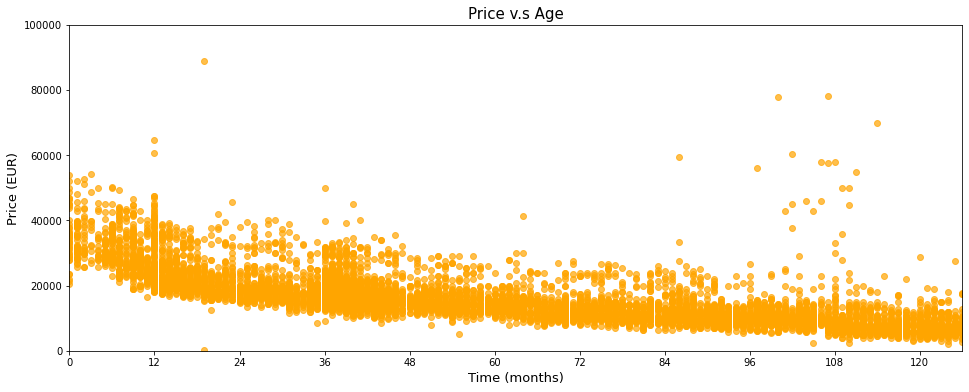

As said, only the cars register firstly from Jan 2010 were scraped, thus the maximum of time is 126 months.

In a reasonable way, I will establish a exponential model for fitting price and the number of months, because in most cases, price decreases by time and it will never go beneath zero (you will not sell car by paying yourself).

Define the fit-model and its plot function then we can obtain the fit curve.

```
fitting: price = 29086.245764018116 * exp(-0.011406846543436674 * months)
```

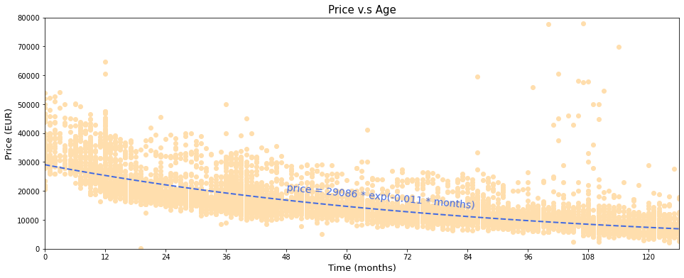

We have to evaluate how good this model is. The first step is to check the distribution of price.

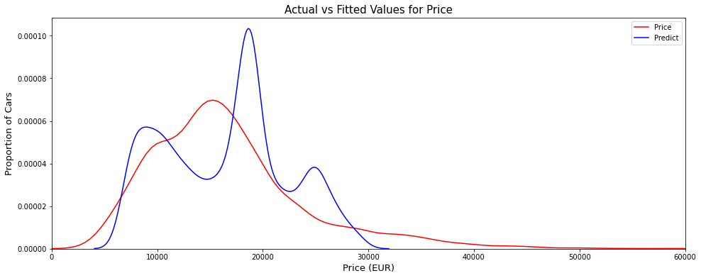

And the plot: actual price vs fitted (predicted) by the exponential model

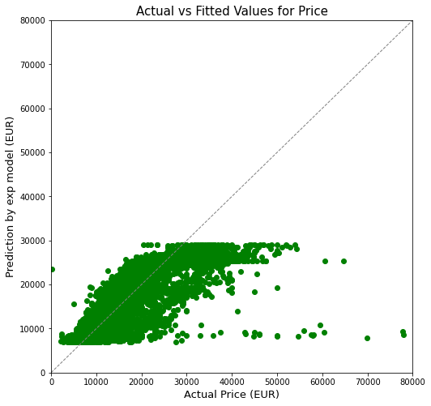

It does not look very well and makes sense as we have not considered the other key factor horsepower yet.

On the other hand, distribution sometimes will not tell exactly the deviation in a datum, it only tells the entire tendence.  
Therefore I am introducing root mean squared error (RMSE) for evaluating the performance.

Let's have a first view of thess criterions.

```
5120 EUR, the root mean squared error between price and prediction
```

Here I would like to show how these error distribute on car models, as it could highly relate to the horsepower.

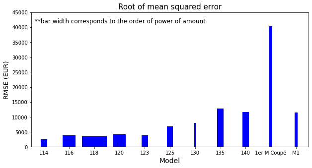

This looks somehow reasonable since the deviation varies with the car model when the other factors are not introduced yet, i.e. the more right side models, the more horsepower they have.  
I will then include horsepower to improve this price prediction model.

## Price model modified with horsepower

At first step, I would like to shortly check if the price between the horsepower significantly recognizible/distinguishable by

1. spliting data into 3 bins - low, medium and high
2. check their ANOVA by each other

```
bins by power range: [  0 150 300 450]
Amount of Low : Medium : High = 6299 : 1913 : 481
```

|  | power_ps | power-binned |
| --- | --- | --- |
| 58 | 95 | Low |
| 59 | 102 | Low |
| 60 | 102 | Low |
| 61 | 102 | Low |
| 62 | 102 | Low |

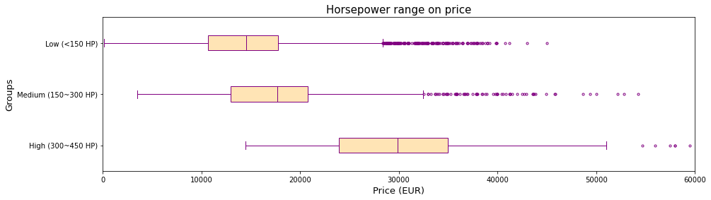

```
Overall ANOVA results: F = 1290.9610758719164 , P = 0.0

Low v.s Medium
  - ANOVA results: f = 277.2581849619185 , p = 2.9824363247923174e-61
Low v.s High
  - ANOVA results: f = 2587.523335998535 , p = 0.0
Medium v.s High
  - ANOVA results: f = 1143.1006068383683 , p = 3.6909067156024394e-205
```

Since the F-values are very high and P-values are very close to 0, in 95% level of significance, null hypothesis is rejected. Horsepower is assumed having a significance on price.

Following we can check again how does it look like when we add color map on the previous price-months plot.

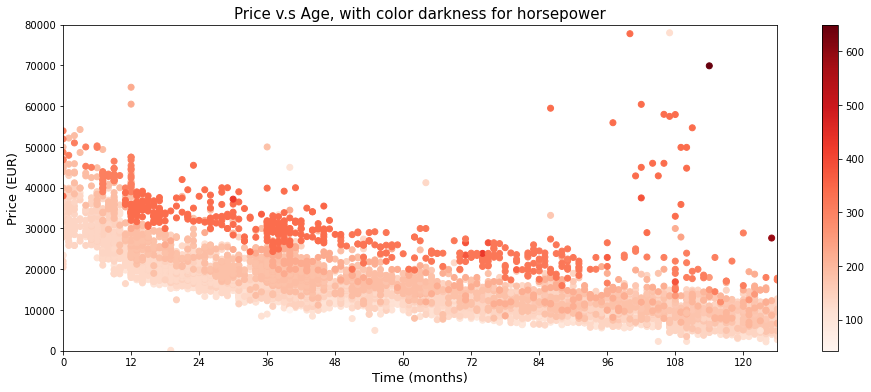

This plot makes the overview in a clearer way.

Here I slightly change the evaluation criterions by removing the absolute operator, in order to know the linearity and correlation between horsepower and the error/differences.

|  | power_ps | rmse |
| --- | --- | --- |
| power_ps | 1.000000 | 0.708129 |
| rmse | 0.708129 | 1.000000 |

From my point of view, this correlation is absolutely significant. Thus, a linear-fit for horsepower will be attempted here.

Define a new fit-curve function, we can obtain a new prediction model, the predict price below

```
fitting: price = (106.03450733771027*hp + 11846.346256374409) * exp(-0.01061590913617442 * months)
```

(it was - **price = 29086.245764018116 *exp(-0.011406846543436674* months)**)

By the same concept, the criterions for evaluating deviation can also be modified like below:

```
3751 EUR, the root mean squared error between price and prediction
```

remembered, it was **5120** EUR  
- the errors decreased significantly.

This also reflects in the chart.

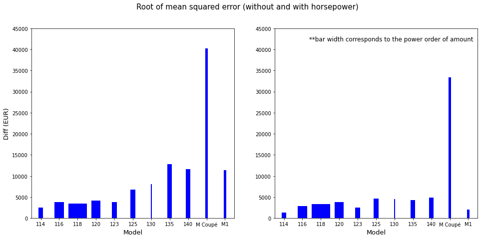

```
Hint for hidden cell: process done!
```

We can see, by considering the horsepower, the RMSE of the models on the right side decreased significantly. Now they have the similar RMSE level compared to the models left side who have less horsepower. Compensating horsepower does really work.  
1er M Coupé is a special model. Even though the horsepower has been considered, its prices still have obvious error.  
Same phenomenon below in the plot.

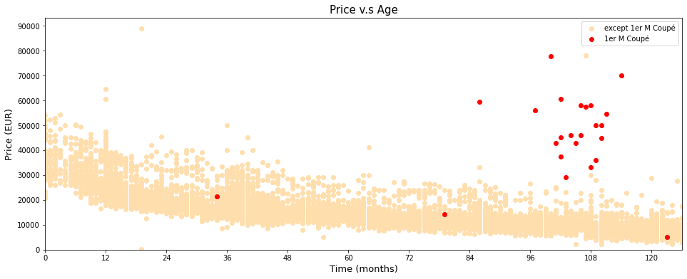

1er M Coupé is an old model and has a special appearance compared to the current style. It could be the key factor that they are being sold with much higher price. We will look more into details for 1er M Coupé later.

And even the distribution has a significant improvement.

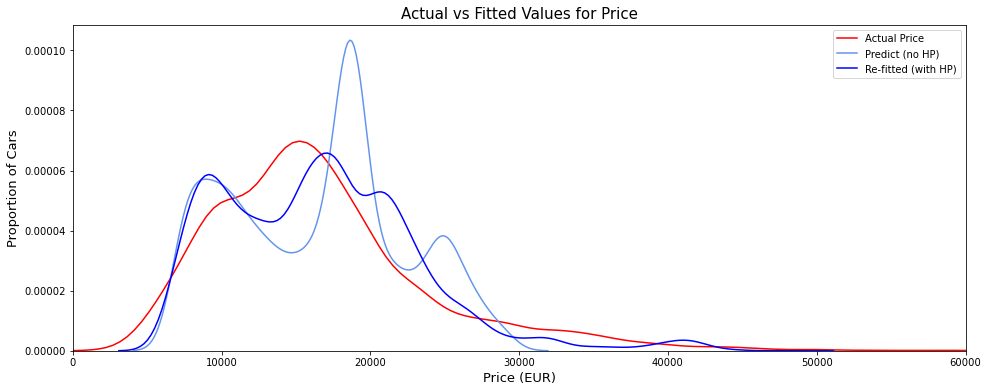

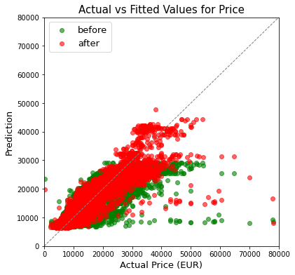

This looks much better, but still far from good. Thus, I will introduce machine learning regression for price prediction.

## Price predict - regression by machine learning with NLP

We have created a price prediction model by the age and horsepower, nevertheless there are still some factors, which are not so influential as age and horsepower, but very helpful for us to enhance the performance.

For example, 1er M Coupé has the same horsepower as 140, which means, if they also have the same age, we will not able to tell the difference of their prices, contradicted to what we've seen, that **1er M Coupé always has a better price**. In that way, if we could take category 'model' into account and then the '1er M Coupé' will be a variance of the price, it could help improving the price prediction model.

For these cases, the following tasks will be done in this section:

1. convert data from string to boolean or one-hot to integers for some categories having only few or fixed options, e.g.  
   {'gear_type': 'automatic', 'manual'} --> {'automatic': True, False}  
   {'condition':'Gebracht', 'Jahreswagen', 'Vorführfahrzeug', 'Tageszulassung', 'Neu'} --> {'condition': 0, 1, 2, 3, 4}
2. scalarize categories with wide range of integer of fload
3. vectorize categories with tags or text or tokens
4. wrangle data as above as input, and the error (difference in price) as output, then split them into train and test sets
5. create pipeline and grid search for tuning/traning machine learning model

### Feature Engineering

The target here is to numerize features so that they can be used in machine learning model.  
Steps:

1. remove features which have too many -1 (unknown) or 'unknown' value, such as 'particulate_sticker', 'consume_in_town', 'consume_out_of_town', 'reviews', 'country_ver',
2. remove the instances having -1 as unknown in a few features, such as 'owner', 'doors', 'seats', 'emission', 'consume_combine'
3. onehot for categorized features, such as 'model', 'condition', 'gear_type', 'fuel_type', 'drive_type', 'ext_color', 'body', 'emission_class'
4. onehot for categorized lists, such as 'int_color', 'kw_comfort', 'kw_extras', 'kw_media', 'kw_safety', 'tags'
5. scalarize numerical features, such as 'consume_combine', 'mileage', 'emission', 'mileage', 'emission', 'age_mon', 'power_ps', 'owner', 'next_HU', 'eng_disp', 'doors', 'seats'
6. vectorized by tfidf for description, in order to get tokens and distributions
7. remove not needed features, such as 'series','guarantee_months', 'postcode', 'city', 'first_reg', 'seller'

Let's see firstly which columns can be binarized, one-hotted, scalarized or vectorized:

```
series : one-hottable **
model : one-hottable **
price : scalarizable **
condition : one-hottable **
gear_type : one-hottable **
fuel_type : one-hottable **
mileage : scalarizable **
first_reg : not classified
age_mon : scalarizable **
power_ps : scalarizable **
owner : no action
guarantee_months : one-hottable **
smoke-free : no action
next_HU : scalarizable **
full_service_history : no action
drive_type : one-hottable **
eng_disp : scalarizable **
doors : no action
ext_color : one-hottable **
int_color : one-hottable list**
body : one-hottable **
country_ver : one-hottable **
seats : no action
emission : scalarizable **
particulate_sticker : no action
consume_combine : scalarizable **
consume_in_town : scalarizable **
consume_out_of_town : scalarizable **
emission_class : one-hottable **
seller : vectorizable **
postcode : vectorizable **
city : vectorizable **
reviews : scalarizable **
kw_comfort : one-hottable list**
kw_extras : one-hottable list**
kw_media : one-hottable list**
kw_safety : one-hottable list**
tags : one-hottable list**
description : vectorizable **
```

Here I will choose the following 22 columns/categories for machine learning model,

- **power_ps, mileage, age_mon**: scalarized and seen as compensation of our previos model
- **next_HU**: scalarized how long till next official examination
- **automatic, Diesel, private_seller**: binarized from gear_type, fuel_type and vendor(private/dealer)
- **condition_onehotted**: from {'Gebracht', 'Jahreswagen', 'Vorführfahrzeug', 'Tageszulassung', 'Neu'} to {0, 1, 2, 3, 4}
- **guarantee_binarized, smoke-free, full_service_history**: from Yes/No to True/False
- **owner, doors**: kept same
- **consume_combine**: scalarized
- **model, kw_comfort, kw_extras, kw_media, kw_safety, tags, ext_color, description**: vectorized for tags/tokens/words

And clean out the data which miss these info.

```
Hint for hidden cell: data wrangling done
df_modelling has 7140 data and 30 columns
```

```
15 features are numerical
```

|  | count | mean | std | min | 25% | 50% | 75% | max |
| --- | --- | --- | --- | --- | --- | --- | --- | --- |
| price | 7140.0 | 17176.718768 | 7575.269138 | 123.0 | 12300.00 | 15950.0 | 19990.25 | 88834.0 |
| mileage | 7140.0 | 61853.593697 | 49636.616827 | 0.0 | 23964.25 | 49065.0 | 88785.00 | 800000.0 |
| age_mon | 7140.0 | 52.089636 | 33.132212 | 0.0 | 29.00 | 41.0 | 78.00 | 126.0 |
| power_ps | 7140.0 | 152.830392 | 50.429429 | 42.0 | 116.00 | 136.0 | 170.00 | 430.0 |
| owner | 7140.0 | 1.405042 | 0.626114 | 0.0 | 1.00 | 1.0 | 2.00 | 5.0 |
| smoke-free | 7140.0 | 0.622409 | 0.484818 | 0.0 | 0.00 | 1.0 | 1.00 | 1.0 |
| next_HU | 7140.0 | 15.344538 | 11.058722 | -39.0 | 4.00 | 21.0 | 24.00 | 40.0 |
| full_service_history | 7140.0 | 0.674370 | 0.468643 | 0.0 | 0.00 | 1.0 | 1.00 | 1.0 |
| eng_disp | 7140.0 | 1792.729272 | 359.971952 | 4.0 | 1499.00 | 1598.0 | 1995.00 | 3000.0 |
| doors | 7140.0 | 4.337955 | 0.957385 | 2.0 | 4.00 | 5.0 | 5.00 | 5.0 |
| seats | 7140.0 | 4.892157 | 0.311556 | 2.0 | 5.00 | 5.0 | 5.00 | 5.0 |
| emission | 7140.0 | 127.596499 | 154.758474 | 89.0 | 114.00 | 123.0 | 133.00 | 13035.0 |
| consume_combine | 7140.0 | 5.193403 | 0.966920 | 3.0 | 4.40 | 5.3 | 5.70 | 10.1 |
| private_seller | 7140.0 | 0.207563 | 0.405591 | 0.0 | 0.00 | 0.0 | 0.00 | 1.0 |
| guarantee_binarized | 7140.0 | 0.582213 | 0.493229 | 0.0 | 0.00 | 1.0 | 1.00 | 1.0 |

First step, scalarize numerical features (which have been binarized will not be included).  
Considering the data distribution, different features will adopt different scalers

- StandardScaler: 'consume_combine'
- RobustScaler: 'mileage', 'emission' (against typo and outliers)
- MinMaxScaler: 'age_mon', 'power_ps', 'owner', 'next_HU', 'eng_disp', 'doors', 'seats'

```
15 features are numerical
```

|  | count | mean | std | min | 25% | 50% | 75% | max |
| --- | --- | --- | --- | --- | --- | --- | --- | --- |
| price | 7140.0 | 1.717672e+04 | 7575.269138 | 123.000000 | 12300.000000 | 15950.000000 | 19990.250000 | 88834.000000 |
| mileage | 7140.0 | 1.972917e-01 | 0.765752 | -0.756934 | -0.387233 | 0.000000 | 0.612767 | 11.584793 |
| age_mon | 7140.0 | 4.134098e-01 | 0.262954 | 0.000000 | 0.230159 | 0.325397 | 0.619048 | 1.000000 |
| power_ps | 7140.0 | 2.856453e-01 | 0.129973 | 0.000000 | 0.190722 | 0.242268 | 0.329897 | 1.000000 |
| owner | 7140.0 | 2.810084e-01 | 0.125223 | 0.000000 | 0.200000 | 0.200000 | 0.400000 | 1.000000 |
| smoke-free | 7140.0 | 6.224090e-01 | 0.484818 | 0.000000 | 0.000000 | 1.000000 | 1.000000 | 1.000000 |
| next_HU | 7140.0 | 6.879055e-01 | 0.139984 | 0.000000 | 0.544304 | 0.759494 | 0.797468 | 1.000000 |
| full_service_history | 7140.0 | 6.743697e-01 | 0.468643 | 0.000000 | 0.000000 | 1.000000 | 1.000000 | 1.000000 |
| eng_disp | 7140.0 | 5.970391e-01 | 0.120151 | 0.000000 | 0.498999 | 0.532043 | 0.664553 | 1.000000 |
| doors | 7140.0 | 7.793184e-01 | 0.319128 | 0.000000 | 0.666667 | 1.000000 | 1.000000 | 1.000000 |
| seats | 7140.0 | 9.640523e-01 | 0.103852 | 0.000000 | 1.000000 | 1.000000 | 1.000000 | 1.000000 |
| emission | 7140.0 | 2.419210e-01 | 8.145183 | -1.789474 | -0.473684 | 0.000000 | 0.526316 | 679.578947 |
| consume_combine | 7140.0 | -5.746726e-15 | 1.000070 | -2.268602 | -0.820604 | 0.110251 | 0.523965 | 5.074814 |
| private_seller | 7140.0 | 2.075630e-01 | 0.405591 | 0.000000 | 0.000000 | 0.000000 | 0.000000 | 1.000000 |
| guarantee_binarized | 7140.0 | 5.822129e-01 | 0.493229 | 0.000000 | 0.000000 | 1.000000 | 1.000000 | 1.000000 |

Then one-hot categorical features

```
model has been one-hotted
condition has been one-hotted
gear_type has been one-hotted
fuel_type has been one-hotted
drive_type has been one-hotted
ext_color has been one-hotted
body has been one-hotted
emission_class has been one-hotted

61 features are numerical
```

|  | count | mean | std | min | 25% | 50% | 75% | max |
| --- | --- | --- | --- | --- | --- | --- | --- | --- |
| price | 7140.0 | 17176.718768 | 7575.269138 | 123.000000 | 12300.000000 | 15950.000000 | 19990.250000 | 88834.000000 |
| mileage | 7140.0 | 0.197292 | 0.765752 | -0.756934 | -0.387233 | 0.000000 | 0.612767 | 11.584793 |
| age_mon | 7140.0 | 0.413410 | 0.262954 | 0.000000 | 0.230159 | 0.325397 | 0.619048 | 1.000000 |
| power_ps | 7140.0 | 0.285645 | 0.129973 | 0.000000 | 0.190722 | 0.242268 | 0.329897 | 1.000000 |
| owner | 7140.0 | 0.281008 | 0.125223 | 0.000000 | 0.200000 | 0.200000 | 0.400000 | 1.000000 |
| ... | ... | ... | ... | ... | ... | ... | ... | ... |
| emission_class_Euro_5 | 7140.0 | 0.236695 | 0.425083 | 0.000000 | 0.000000 | 0.000000 | 0.000000 | 1.000000 |
| emission_class_Euro_6 | 7140.0 | 0.659664 | 0.473855 | 0.000000 | 0.000000 | 1.000000 | 1.000000 | 1.000000 |
| emission_class_Euro_6c | 7140.0 | 0.004202 | 0.064689 | 0.000000 | 0.000000 | 0.000000 | 0.000000 | 1.000000 |
| emission_class_Euro_6d | 7140.0 | 0.003501 | 0.059073 | 0.000000 | 0.000000 | 0.000000 | 0.000000 | 1.000000 |
| emission_class_Euro_6d-TEMP | 7140.0 | 0.046639 | 0.210878 | 0.000000 | 0.000000 | 0.000000 | 0.000000 | 1.000000 |

61 rows × 8 columns

```
int_color has been one-hotted
kw_comfort has been one-hotted
kw_extras has been one-hotted
kw_media has been one-hotted
kw_safety has been one-hotted
tags has been one-hotted

325 features are numerical
```

|  | count | mean | std | min | 25% | 50% | 75% | max |
| --- | --- | --- | --- | --- | --- | --- | --- | --- |
| price | 7140.0 | 17176.718768 | 7575.269138 | 123.000000 | 12300.000000 | 15950.000000 | 19990.250000 | 88834.000000 |
| mileage | 7140.0 | 0.197292 | 0.765752 | -0.756934 | -0.387233 | 0.000000 | 0.612767 | 11.584793 |
| age_mon | 7140.0 | 0.413410 | 0.262954 | 0.000000 | 0.230159 | 0.325397 | 0.619048 | 1.000000 |
| power_ps | 7140.0 | 0.285645 | 0.129973 | 0.000000 | 0.190722 | 0.242268 | 0.329897 | 1.000000 |
| owner | 7140.0 | 0.281008 | 0.125223 | 0.000000 | 0.200000 | 0.200000 | 0.400000 | 1.000000 |
| ... | ... | ... | ... | ... | ... | ... | ... | ... |
| tags_winterpaket | 7140.0 | 0.001261 | 0.035484 | 0.000000 | 0.000000 | 0.000000 | 0.000000 | 1.000000 |
| tags_winterreifen | 7140.0 | 0.057563 | 0.232932 | 0.000000 | 0.000000 | 0.000000 | 0.000000 | 1.000000 |
| tags_xenonscheinwerfer | 7140.0 | 0.105322 | 0.306990 | 0.000000 | 0.000000 | 0.000000 | 0.000000 | 1.000000 |
| tags_zentralverriegelung | 7140.0 | 0.104762 | 0.306268 | 0.000000 | 0.000000 | 0.000000 | 0.000000 | 1.000000 |
| tags_zentralverriegelung_mit_funkfernbedienung | 7140.0 | 0.014986 | 0.121505 | 0.000000 | 0.000000 | 0.000000 | 0.000000 | 1.000000 |

325 rows × 8 columns

Now, the last step, we will vectorize the description column

```
6672 features are numerical
```

|  | count | mean | std | min | 25% | 50% | 75% | max |
| --- | --- | --- | --- | --- | --- | --- | --- | --- |
| price | 7140.0 | 17176.718768 | 7575.269138 | 123.000000 | 12300.000000 | 15950.000000 | 19990.250000 | 88834.000000 |
| mileage | 7140.0 | 0.197292 | 0.765752 | -0.756934 | -0.387233 | 0.000000 | 0.612767 | 11.584793 |
| age_mon | 7140.0 | 0.413410 | 0.262954 | 0.000000 | 0.230159 | 0.325397 | 0.619048 | 1.000000 |
| power_ps | 7140.0 | 0.285645 | 0.129973 | 0.000000 | 0.190722 | 0.242268 | 0.329897 | 1.000000 |
| owner | 7140.0 | 0.281008 | 0.125223 | 0.000000 | 0.200000 | 0.200000 | 0.400000 | 1.000000 |
| ... | ... | ... | ... | ... | ... | ... | ... | ... |
| überweisung | 7140.0 | 0.000110 | 0.004432 | 0.000000 | 0.000000 | 0.000000 | 0.000000 | 0.230441 |
| überwiegend | 7140.0 | 0.000207 | 0.006920 | 0.000000 | 0.000000 | 0.000000 | 0.000000 | 0.337470 |
| überzeugen | 7140.0 | 0.000823 | 0.010989 | 0.000000 | 0.000000 | 0.000000 | 0.000000 | 0.307585 |
| überzeugt | 7140.0 | 0.000138 | 0.005215 | 0.000000 | 0.000000 | 0.000000 | 0.000000 | 0.323095 |
| üblichen | 7140.0 | 0.000367 | 0.009188 | 0.000000 | 0.000000 | 0.000000 | 0.000000 | 0.346675 |

6672 rows × 8 columns

### Train test set split

Here I set a random state so that the reproducibility can be ensured.

```
X_train.shape (5712, 6671)
X_test.shape (1428, 6671)
y_train.shape (5712,)
y_test.shape (1428,)
```

```
X_train
```

|  | mileage | age_mon | power_ps | owner | smoke-free | next_HU | full_service_history | eng_disp | doors | seats | ... | überraschen | übersicht | übertragungsfehler | übertragungsfehlern | überwachung | überweisung | überwiegend | überzeugen | überzeugt | üblichen |
| --- | --- | --- | --- | --- | --- | --- | --- | --- | --- | --- | --- | --- | --- | --- | --- | --- | --- | --- | --- | --- | --- |
| 6027 | -0.681032 | 0.087302 | 0.242268 | 0.2 | 1 | 0.810127 | 1 | 0.498999 | 0.666667 | 1.000000 | ... | 0.0 | 0.0 | 0.0 | 0.0 | 0.0 | 0.0 | 0.0 | 0.0 | 0.0 | 0.000000 |
| 5337 | 0.104041 | 0.301587 | 0.278351 | 0.4 | 0 | 0.797468 | 0 | 0.664553 | 0.333333 | 0.666667 | ... | 0.0 | 0.0 | 0.0 | 0.0 | 0.0 | 0.0 | 0.0 | 0.0 | 0.0 | 0.000000 |
| 8044 | -0.756841 | 0.015873 | 0.381443 | 0.2 | 1 | 0.924051 | 1 | 0.664553 | 1.000000 | 1.000000 | ... | 0.0 | 0.0 | 0.0 | 0.0 | 0.0 | 0.0 | 0.0 | 0.0 | 0.0 | 0.000000 |
| 3628 | 1.294971 | 0.793651 | 0.260309 | 0.4 | 1 | 0.797468 | 1 | 0.664553 | 0.666667 | 1.000000 | ... | 0.0 | 0.0 | 0.0 | 0.0 | 0.0 | 0.0 | 0.0 | 0.0 | 0.0 | 0.140525 |
| 1876 | 0.137842 | 0.507937 | 0.242268 | 0.4 | 1 | 0.797468 | 1 | 0.532043 | 1.000000 | 1.000000 | ... | 0.0 | 0.0 | 0.0 | 0.0 | 0.0 | 0.0 | 0.0 | 0.0 | 0.0 | 0.000000 |

5 rows × 6671 columns

```
X_test
```

|  | mileage | age_mon | power_ps | owner | smoke-free | next_HU | full_service_history | eng_disp | doors | seats | ... | überraschen | übersicht | übertragungsfehler | übertragungsfehlern | überwachung | überweisung | überwiegend | überzeugen | überzeugt | üblichen |
| --- | --- | --- | --- | --- | --- | --- | --- | --- | --- | --- | --- | --- | --- | --- | --- | --- | --- | --- | --- | --- | --- |
| 3948 | -0.101974 | 0.595238 | 0.260309 | 0.2 | 1 | 0.632911 | 1 | 0.664553 | 0.666667 | 1.0 | ... | 0.0 | 0.0 | 0.0 | 0.0 | 0.0 | 0.0 | 0.0 | 0.0 | 0.0 | 0.0 |
| 6490 | -0.608339 | 0.031746 | 0.252577 | 0.2 | 1 | 0.493671 | 1 | 0.498999 | 1.000000 | 1.0 | ... | 0.0 | 0.0 | 0.0 | 0.0 | 0.0 | 0.0 | 0.0 | 0.0 | 0.0 | 0.0 |
| 7184 | 0.430958 | 0.341270 | 0.381443 | 0.2 | 1 | 0.797468 | 1 | 0.664553 | 0.666667 | 1.0 | ... | 0.0 | 0.0 | 0.0 | 0.0 | 0.0 | 0.0 | 0.0 | 0.0 | 0.0 | 0.0 |
| 1012 | 1.703698 | 0.785714 | 0.190722 | 0.4 | 0 | 0.493671 | 0 | 0.664553 | 1.000000 | 1.0 | ... | 0.0 | 0.0 | 0.0 | 0.0 | 0.0 | 0.0 | 0.0 | 0.0 | 0.0 | 0.0 |
| 1977 | 0.043736 | 0.341270 | 0.172680 | 0.2 | 1 | 0.405063 | 1 | 0.498999 | 0.333333 | 1.0 | ... | 0.0 | 0.0 | 0.0 | 0.0 | 0.0 | 0.0 | 0.0 | 0.0 | 0.0 | 0.0 |

5 rows × 6671 columns

### First try on linear regression

```
train score: 0.9927965945430273
test score: -780.2664491851914
```

A high train score (close to 1) and negative test score always mean an over-fitting. Following the gridsearch with regularization will be established, so that a more fine-tunned regression can be ensured.

### Gridsearch with regularization

Here I am adopting regularizational regressor and running them with different measures of regularization (alpha).

```
GridSearchCV(cv=4, estimator=Pipeline(steps=[('estimator', DummyEstimator())]),
             param_grid=[{'estimator': [Ridge(max_iter=10000)],
                          'estimator__alpha': array([1.e-03, 1.e-02, 1.e-01, 1.e+00, 1.e+01, 1.e+02, 1.e+03])},
                         {'estimator': [Lasso(max_iter=10000)],
                          'estimator__alpha': array([1.e-03, 1.e-02, 1.e-01, 1.e+00, 1.e+01, 1.e+02, 1.e+03])},
                         {'estimator': [ElasticNet(max_iter=10000)],
                          'estimator__alpha': array([1.e-03, 1.e-02, 1.e-01, 1.e+00, 1.e+01, 1.e+02, 1.e+03]),
                          'estimator__l1_ratio': [0.1, 0.2, 0.3, 0.4, 0.5, 0.6,
                                                  0.7, 0.8, 0.9]}])
```

```
best score: 0.9192606506660969
```

```
Pipeline(steps=[('estimator', Lasso(max_iter=10000))])
```

The best regressor with hyperparameter.

```
{'estimator': Lasso(max_iter=10000), 'estimator__alpha': 1.0}
```

```
best score by train set: 0.9414480300560546
best score by test set: 0.8678729673306254
```

And distribution plots:

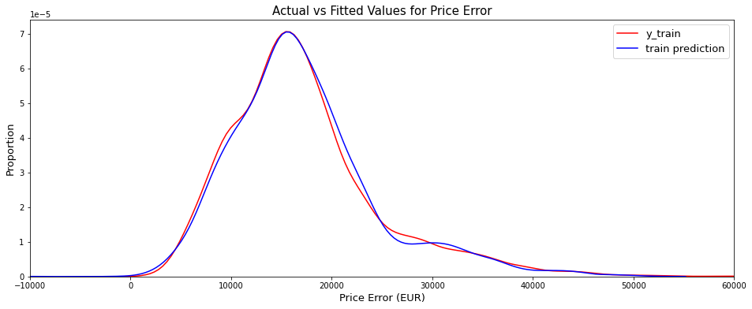

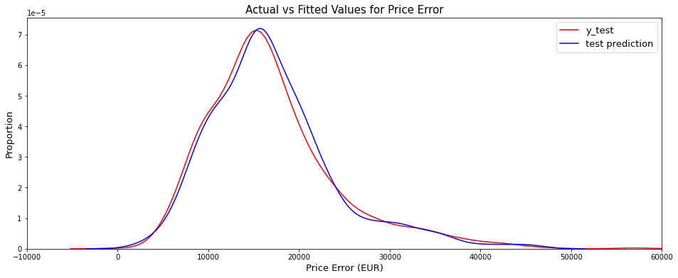

Actual vs prediction plot

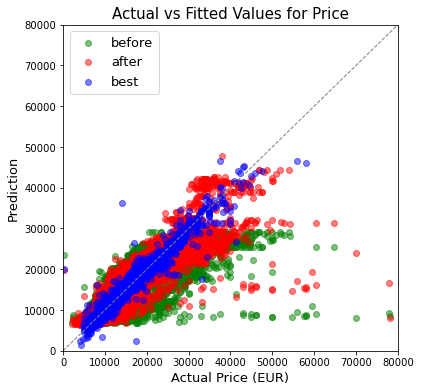

We can see both from distribution or the actual vs prediction plot the performance.

### Improvement by the exponential model

As we mentioned before, compared the linear model, the age vs price approachs more likely in exponential. Here I will add a feature called "age_mon_exp" and will adopt the coefficient we got before and see how much it will be improved.  
At first, I will calculate **age_mon_exp = exp(-0.01061590913617442 * months)** then scale it by MinMaxScaler.

```
count    7140.000000
mean        0.470029
std         0.261542
min         0.000000
25%         0.236508
50%         0.521511
75%         0.640714
max         1.000000
Name: age_mon_exp, dtype: float64
```

Re-split it and keep the same random state, check they are using the same sets.

```
X_train.shape (5712, 6671)
X_test.shape (1428, 6671)
y_train.shape (5712,)
y_test.shape (1428,)
```

```
X_train
```

|  | mileage | power_ps | owner | smoke-free | next_HU | full_service_history | eng_disp | doors | seats | emission | ... | übersicht | übertragungsfehler | übertragungsfehlern | überwachung | überweisung | überwiegend | überzeugen | überzeugt | üblichen | age_mon_exp |
| --- | --- | --- | --- | --- | --- | --- | --- | --- | --- | --- | --- | --- | --- | --- | --- | --- | --- | --- | --- | --- | --- |
| 6027 | -0.681032 | 0.242268 | 0.2 | 1 | 0.810127 | 1 | 0.498999 | 0.666667 | 1.000000 | 0.578947 | ... | 0.0 | 0.0 | 0.0 | 0.0 | 0.0 | 0.0 | 0.0 | 0.0 | 0.000000 | 0.850562 |
| 5337 | 0.104041 | 0.278351 | 0.4 | 0 | 0.797468 | 0 | 0.664553 | 0.333333 | 0.666667 | -0.210526 | ... | 0.0 | 0.0 | 0.0 | 0.0 | 0.0 | 0.0 | 0.0 | 0.0 | 0.000000 | 0.549903 |
| 8044 | -0.756841 | 0.381443 | 0.2 | 1 | 0.924051 | 1 | 0.664553 | 1.000000 | 1.000000 | -0.315789 | ... | 0.0 | 0.0 | 0.0 | 0.0 | 0.0 | 0.0 | 0.0 | 0.0 | 0.000000 | 0.971516 |
| 3628 | 1.294971 | 0.260309 | 0.4 | 1 | 0.797468 | 1 | 0.664553 | 0.666667 | 1.000000 | -0.315789 | ... | 0.0 | 0.0 | 0.0 | 0.0 | 0.0 | 0.0 | 0.0 | 0.0 | 0.140525 | 0.113123 |
| 1876 | 0.137842 | 0.242268 | 0.4 | 1 | 0.797468 | 1 | 0.532043 | 1.000000 | 1.000000 | 0.421053 | ... | 0.0 | 0.0 | 0.0 | 0.0 | 0.0 | 0.0 | 0.0 | 0.0 | 0.000000 | 0.331430 |

5 rows × 6671 columns

```
X_test
```

|  | mileage | power_ps | owner | smoke-free | next_HU | full_service_history | eng_disp | doors | seats | emission | ... | übersicht | übertragungsfehler | übertragungsfehlern | überwachung | überweisung | überwiegend | überzeugen | überzeugt | üblichen | age_mon_exp |
| --- | --- | --- | --- | --- | --- | --- | --- | --- | --- | --- | --- | --- | --- | --- | --- | --- | --- | --- | --- | --- | --- |
| 3948 | -0.101974 | 0.260309 | 0.2 | 1 | 0.632911 | 1 | 0.664553 | 0.666667 | 1.0 | 0.210526 | ... | 0.0 | 0.0 | 0.0 | 0.0 | 0.0 | 0.0 | 0.0 | 0.0 | 0.0 | 0.255678 |
| 6490 | -0.608339 | 0.252577 | 0.2 | 1 | 0.493671 | 1 | 0.498999 | 1.000000 | 1.0 | 0.315789 | ... | 0.0 | 0.0 | 0.0 | 0.0 | 0.0 | 0.0 | 0.0 | 0.0 | 0.0 | 0.943630 |
| 7184 | 0.430958 | 0.381443 | 0.2 | 1 | 0.797468 | 1 | 0.664553 | 0.666667 | 1.0 | -1.052632 | ... | 0.0 | 0.0 | 0.0 | 0.0 | 0.0 | 0.0 | 0.0 | 0.0 | 0.0 | 0.503078 |
| 1012 | 1.703698 | 0.190722 | 0.4 | 0 | 0.493671 | 0 | 0.664553 | 1.000000 | 1.0 | -0.736842 | ... | 0.0 | 0.0 | 0.0 | 0.0 | 0.0 | 0.0 | 0.0 | 0.0 | 0.0 | 0.118129 |
| 1977 | 0.043736 | 0.172680 | 0.2 | 1 | 0.405063 | 1 | 0.498999 | 0.333333 | 1.0 | 0.000000 | ... | 0.0 | 0.0 | 0.0 | 0.0 | 0.0 | 0.0 | 0.0 | 0.0 | 0.0 | 0.503078 |

5 rows × 6671 columns

Run Lasso with alpha again, to see if we will get the same result.

```
GridSearchCV(cv=4, estimator=Lasso(),
             param_grid=[{'alpha': array([1.e-03, 1.e-02, 1.e-01, 1.e+00, 1.e+01, 1.e+02, 1.e+03])}])
```

```
best score: 0.9211314111664719
```

```
{'alpha': 1.0}
```

```
best score by train set: 0.9428426139795761
best score by test set: 0.8702853490373768
```

It was:  
best score by train set: **0.9414480300560546**  
best score by test set: **0.8678729673306254**

Therefore, it really helps for a better performance, but to be honest, not so significant.

Let's go back to the original questions when I wanted to buy a car and see if our model could help.

### Quick question: how much more could an 1er M Coupé cost than M140?

As I mentioned, that the 1er M Coupé has same horsepower as 140. Let's see what kind of difference they have if they have all the same features except the model name.

Select one of the 1er M Coupé data, copy it and edit the model name to 140.

|  | 0 | 1 |
| --- | --- | --- |
| model_125 | 0.0 | 0.0 |
| model_130 | 0.0 | 0.0 |
| model_135 | 0.0 | 0.0 |
| model_140 | 0.0 | 1.0 |
| model_1er_M_Coupé | 1.0 | 0.0 |
| condition_Jahreswagen | 0.0 | 0.0 |
| condition_Neu | 0.0 | 0.0 |
| condition_Tageszulassung | 0.0 | 0.0 |
| condition_Vorführfahrzeug | 0.0 | 0.0 |
| gear_type_automatic | 0.0 | 0.0 |

```
1er M Coupé price diff = 46187 EUR
140 price diff = 24323 EUR
```

Their difference even reaches 22000 EUR.

### Quick question: how much more could automatic cost than manual?

Now, I am able to answer some of the questions I brought out in the beginning: how much more does a automatic car cost than manual?  
Below two data are identical except the column 'automatic', one of which is rewritten to 1 for testing.

|  | 0 | 1 |
| --- | --- | --- |
| condition_Jahreswagen | 0.0 | 0.0 |
| condition_Neu | 0.0 | 0.0 |
| condition_Tageszulassung | 0.0 | 0.0 |
| condition_Vorführfahrzeug | 0.0 | 0.0 |
| gear_type_automatic | 0.0 | 1.0 |
| fuel_type_Benzin | 1.0 | 1.0 |
| drive_type_4wd | 0.0 | 0.0 |
| drive_type_front | 0.0 | 0.0 |
| drive_type_rear | 1.0 | 1.0 |
| ext_color_beige | 0.0 | 0.0 |

```
140 manual price predicted = 28138 EUR
140 automatic price predicted = 29472 EUR
```

Cool, automatic could deserve 1300 EUR more.

And furthermore, what could be the prices when an 140 is sold by dealer and by private seller?

### Quick question: do dealers always sell more expensive than private?

|  | 0 | 1 |
| --- | --- | --- |
| price | 39144.000000 | 39144.000000 |
| mileage | -0.387484 | -0.387484 |
| age_mon | 0.111111 | 0.111111 |
| power_ps | 0.768041 | 0.768041 |
| owner | 0.200000 | 0.200000 |
| smoke-free | 0.000000 | 0.000000 |
| next_HU | 0.797468 | 0.797468 |
| full_service_history | 1.000000 | 1.000000 |
| eng_disp | 0.999332 | 0.999332 |
| doors | 1.000000 | 1.000000 |
| seats | 1.000000 | 1.000000 |
| emission | 3.000000 | 3.000000 |
| consume_combine | 2.799389 | 2.799389 |
| private_seller | 0.000000 | 1.000000 |
| guarantee_binarized | 1.000000 | 1.000000 |

```
140 price by dealer (predicted) = 37466 EUR
140 price by private (predicted) = 37885 EUR
```

Very interesting, the private seller might require almost 400 EUR more than dealer (in this case).

### Significant features

Let's see what play bigger roles for the price.

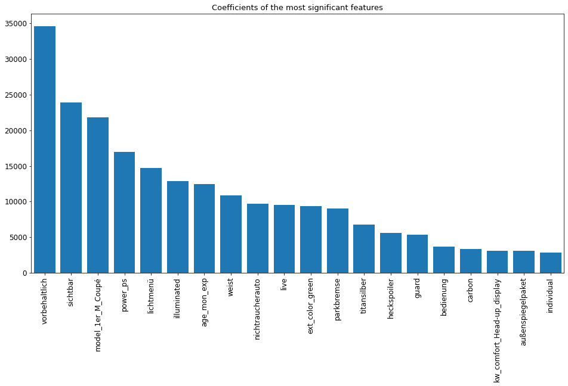

We can see that the 1er_M_Coupé has no wonder has the significance. Besides, power_ps and age_mon_exp are expected to have significance too.

## Summary

This price prediction model can be seen a prework of price recommendation system. What make this model different is that the model was not totally built by machine learning - it contains a reasonable mathematical model, i.e. the exponential, which lead a slightly better performance.

## Future work

# Insight from age of the car

In this section, I will try to find some insight solely from the age of the used car selling on the marktplace.

## Exploration

At the first step, let's have a quick look to the histogram of the amount to different age range.

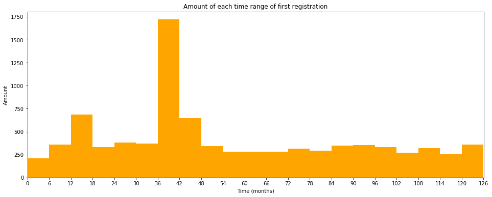

What remarkable here are,

1. the peak locates the range of age 36-42 months
2. a smaller peak in the range 12-18 months

But why these? Does it relate to certain car models?  
Or, does it imply a special sales-mode, that people sell their car shortly after 3 years or 1 year?  
What can we extract from our data?

## Relation between ages and models

For being able to have proper scale for y-axis of following plots, define the plot function here first. Then we can plot the histogram: amount to age for each 1er model.

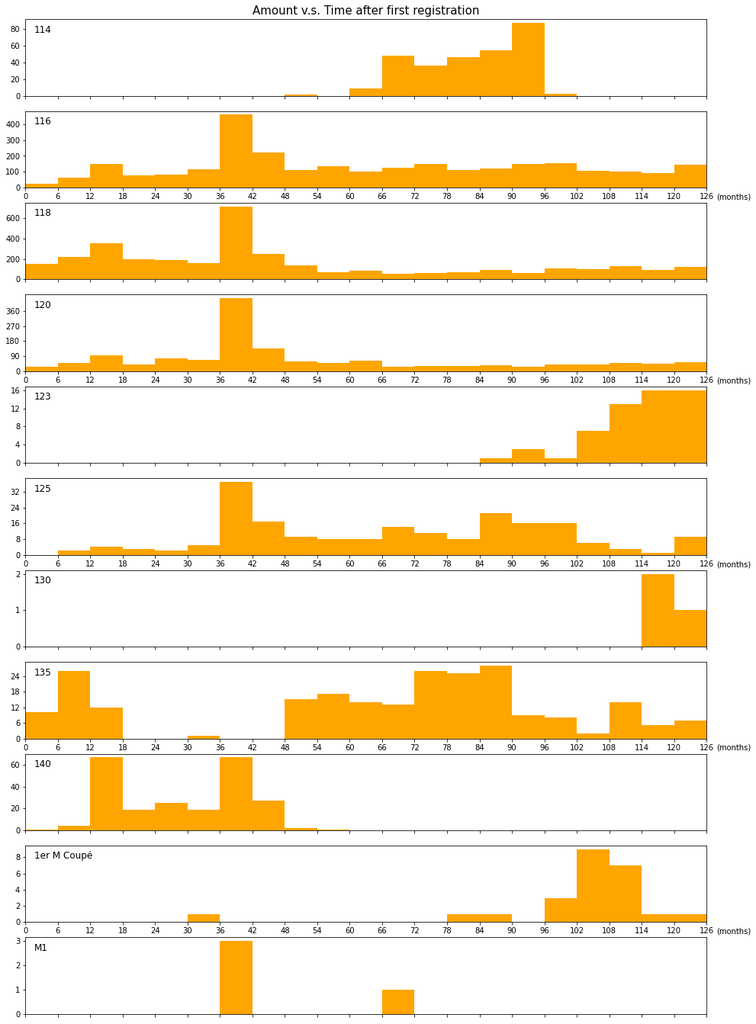

The amounts distribute differently by the model.

But we have to keep in mind, that these only mean **"used cars selling currently"**, not implies **"How many 1er of each model were produced/sold by BMW"**.  
We should not confuse them and hence, no inference of which were sold more/better by BMW. For example, the peak in 36-42 months cannot certainly be intepreted as BMW produced more in this time frame - more prodution could lead this result but could not be a certainty.

Nevertheless, anyway, we are still able to see that some models seem to be stopped for production and some are new types or new generations.

The following data for BMW 1er generations and its production times can be found on Wikipedia.  
For a better overview, I added this info on the plot.

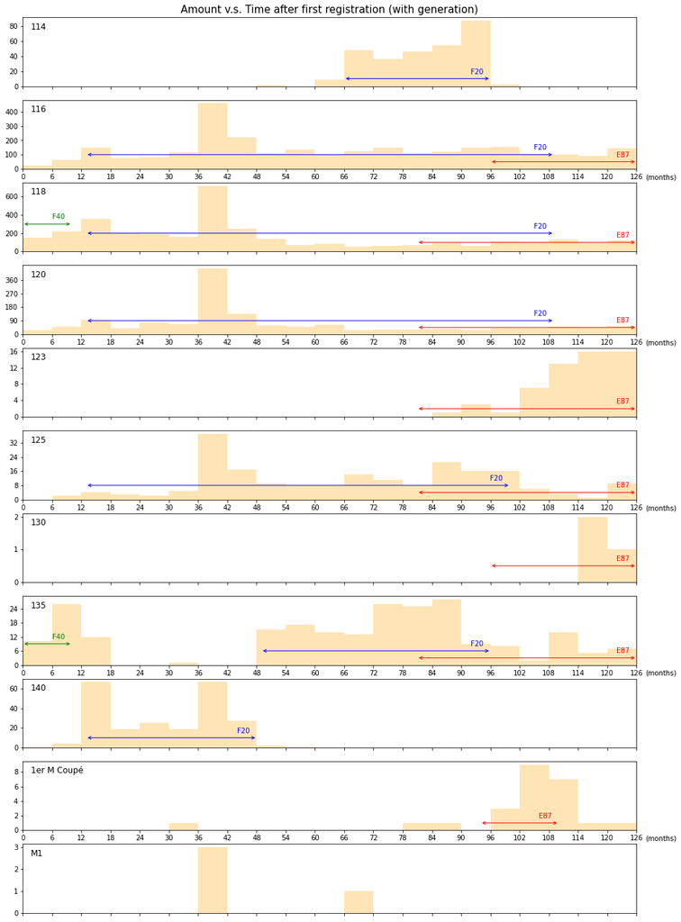

Nevertheless, the peak 12-18 appear for new models let me think of promotion for new generation.  
When it comes to promotion or sales-mode, we should have a look into the vendor, because the private seller cannot provide this promotion as dealers do.

## New promotion ways hide behind - leasing

For the first step, a sub dataframe will be selected out, so that we can seperate the age, condition, and seller type from the entire, in order to see the difference among the age ranges.

|  | age_mon | class_seller_dealer | class_seller_private | condition_Gebraucht | condition_Jahreswagen | condition_Neu | condition_Tageszulassung | condition_Vorführfahrzeug |
| --- | --- | --- | --- | --- | --- | --- | --- | --- |
| 0 | 0 | 209.0 | 2.0 | 53.0 | 21.0 | 1.0 | 9.0 | 127.0 |
| 1 | 6 | 353.0 | 7.0 | 153.0 | 114.0 | 0.0 | 5.0 | 88.0 |
| 2 | 12 | 653.0 | 32.0 | 406.0 | 275.0 | 0.0 | 0.0 | 4.0 |
| 3 | 18 | 285.0 | 48.0 | 326.0 | 3.0 | 0.0 | 1.0 | 3.0 |
| 4 | 24 | 331.0 | 48.0 | 375.0 | 1.0 | 0.0 | 0.0 | 3.0 |

Like above, now we have the amount of seller type, condition to each age range.

Let's see how the amount of seller types relate to the age.

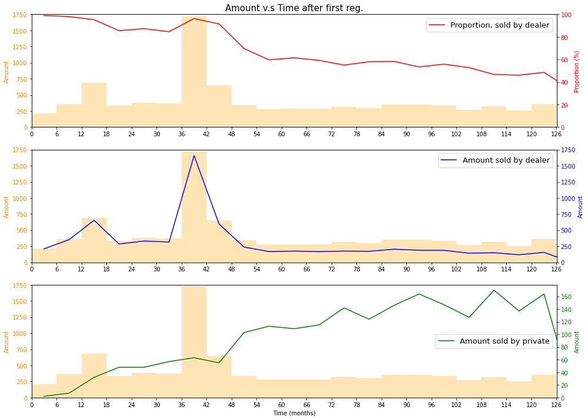

Aha! the peak by dealer perfectly matches it!  
It means that the peak of 36-42 and 12-18 mainly caused by the dealer.  
Compared to that, private sellers contribute not so many to the peaks (but only for older cars.)

Now, again, plot with car conditions:

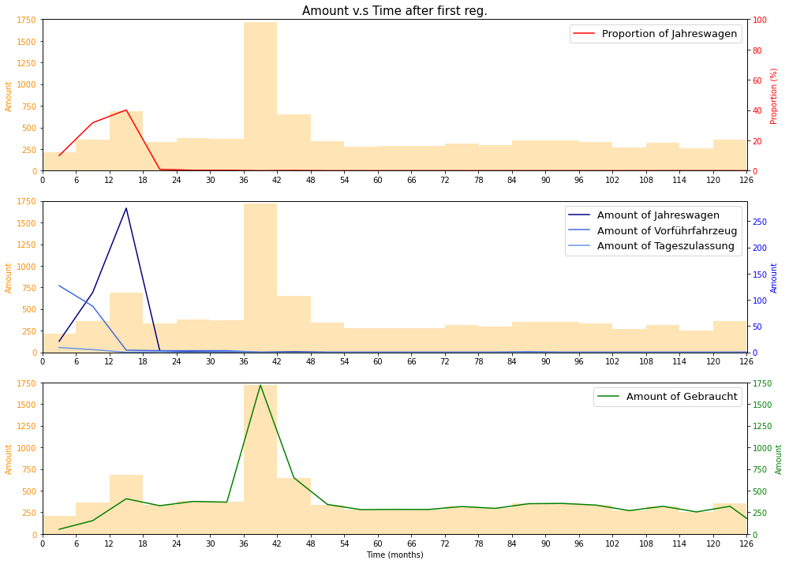

```
Hint for hidden cell: plot done.
```

From the plot, we can see, that the peak 12-18 matchs to the propotion of Jahreswagen, by the definition, produced no longer than 12 months, and usually could be used only by the manufacturer).

Is this true? In that case, the Jahreswagen should mostly be provided by BMW. Let's have a look to the amount/propotion of who sell the car most for different ages.

|  | bins_age_mon | 1st | 2nd | 3rd |
| --- | --- | --- | --- | --- |
| 0 | 0 | Careal GmbH (10), 4% | BMW Niederlassung Frankfurt (9), 4% | Autozentrum Bernhard Ernst (9), 4% |
| 1 | 6 | Cloppenburg GmbH (31), 8% | BMW AG (16), 4% | Emil Frey Ungeheuer Automobile (12), 3% |
| 2 | 12 | BMW AG (54), 7% | private (32), 4% | BMW AG Niederlassung Berlin (23), 3% |
| 3 | 18 | private (48), 14% | Procar Automobile GmbH (28), 8% | Autohaus Bilia GmbH (15), 4% |
| 4 | 24 | private (48), 12% | Autohaus Baltes (44), 11% | Sixt Car Sales (21), 5% |
| 5 | 30 | private (57), 15% | BMW AG (14), 3% | Sixt Car Sales (13), 3% |
| 6 | 36 | BMW AG Niederlassung Dreieich (81), 4% | BMW AG (77), 4% | private (63), 3% |
| 7 | 42 | private (55), 8% | Autohaus Bilia GmbH (22), 3% | DAT AUTOHUS AG (18), 2% |
| 8 | 48 | private (103), 30% | DAT AUTOHUS AG (6), 1% | BMW AH Rhein GmbH (4), 1% |
| 9 | 54 | private (113), 40% | DAT AUTOHUS AG (9), 3% | Autohaus Fahrfreude GmbH+None (5), 1% |
| 10 | 60 | private (109), 38% | DAT AUTOHUS AG (10), 3% | Autohaus Schaumberger GmbH (3), 1% |
| 11 | 66 | private (115), 40% | DAT AUTOHUS AG (3), 1% | Cloppenburg GmbH (3), 1% |
| 12 | 72 | private (142), 44% | ALLCARS-EU GmbH (4), 1% | Autohaus Menke GmbH (2), 0% |
| 13 | 78 | private (124), 42% | Auto-Technik Dähne GmbH (2), 0% | Autohaus Enes GmbH (2), 0% |
| 14 | 84 | private (146), 41% | Autohaus Kober (3), 0% | Auto-Treff 24 GmbH (2), 0% |
| 15 | 90 | private (164), 46% | Auto Technik Ayranci (2), 0% | Autohaus Stahmer GmbH (2), 0% |
| 16 | 96 | private (147), 44% | Autohaus Kühnert GmbH (2), 0% | Kamux Auto GmbH (2), 0% |
| 17 | 102 | private (127), 47% | Autohaus Unterberger GmbH (3), 1% | Time Cars (2), 0% |
| 18 | 108 | private (170), 53% | Autohaus EcoFriendly Import Export (2), 0% | Auto-Handel-Teltow (2), 0% |
| 19 | 114 | private (137), 53% | Autohaus Dörrschuck (2), 0% | Tari Automobile GbR (2), 0% |
| 20 | 120 | private (164), 51% | EFE Automobile (3), 0% | Autohaus Marsani GmbH (2), 0% |
| 21 | 126 | private (25), 65% | Automobile Maatouk+None (1), 2% | M+M (1), 2% |

## Summary

I have been aware of the trend of leasing cars, but had not known that this re-sold leasing cars contribute so many proportion to the second-hand market. And furtunately, this research provides this insight.

## Future work

This is though a smaller research compared to the price prediction, I still can improve it by

1. NLP, so that I might know if the re-sold leasing cars has certain keywords.